# Market Structures

October 24, 2018

## Safety

- Campus police will provide escorts: (509) 335-8548.
- Alternatives to Violence of the Palouse: (509) 332-HELP (4357).
- Crisis hotline: 1-866-871-6385.

If you need help, faculty are not trained, but they are supposed to maintain confidentiality, though they may have to inform department directors and cougar health services in certain circumstances.

## Markets and Civic Life

[video not shown]

## Dimensions of market structure

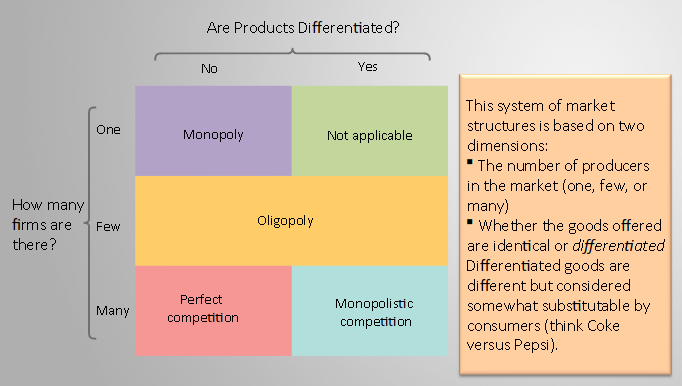

Market Structure (Krugman and Wells).

## Perfect competition

- **Price-Taking** - A producer or consumer who does not have enough influence on the market to affect prices. A price-taking producer must set their price at or below the market price. A price-taking consumer must offer a price at least as high as the market price.

If both consumers and producers are price-taking, we say the market is **perfectly competitive**.

If just producers are price-takers, it is a **perfectly competitive industry**.

## Perfect competition requirements

- There must be enough producers and no producer can have a large enough **market share** to affect prices. (E.g. corner stores and gas stations)

(**market share** is the fraction of total revenue for the industry made up from a particular firm’s revenues.)

- Consumers must regard the good from all firms as equivalent to each other. Goods are **perfect substitutes**. (E.g. oranges or other fruits, perhaps pens, bread.)
- Free entry and exit of firms (other firms can’t keep firms out). (E.g. any business that requires licensing is not a competitive market.)

## Perfect Competition in the short run

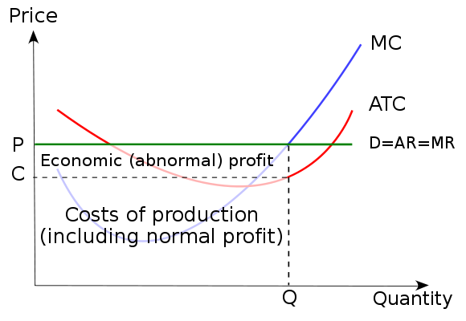

## Perfect Competition in the long run

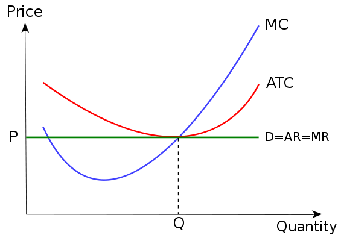

## Monopoly

- One firm produces the good.
- Since there is one firm, that firm can set the price.

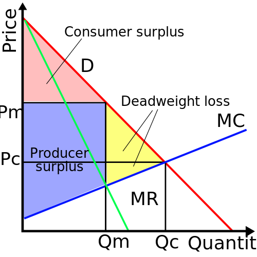

## Monopoly requirements

A monopolist **must** keep other firms from entering the market:

- Control natural resources (DeBeers diamonds).
- Technological superiority (Other firms can’t produce).
- Increasing returns to scale (they can produce more cheaply).
- Government barriers: licenses, copyright, patents

## Oligopoly

- An **oligopoly** is a few firms that have some price-setting power. Oligopolist firms can set prices to some extent, can collude to reduce production and/or elevate prices, and otherwise extort additional profits from consumers.
- The typical oligopoly game theory problem is the prisoner’s dilemma. Do firms collude and keep output low and prices high? Or do they cheat?

## Oligopoly collusion

[video not shown]

## Measuring market concentration

The **Herfindal-Hirschman Index (HHI)** measures market concentration, and is the sum of squared market shares. For example, if Amazon, Wal-Mart, Target, and five other smaller competitors have market shares of \(25%\), \(45%\), \(15%\), and \(5%\) each, the HHI is

\[HHI = 25^2 + 45^2 + 15^2 + 5 \times 5^2 = 3,000.\]

What’s your intuition on:

- Airplanes
- Diamond mining
- Movie production
- Retail

## Market concentration for some markets

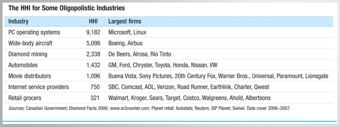

## Monopolistic Competition

All of the previous markets assume goods that are indistinquishable to consumers.

But what if goods *are* distinguishable, or at least *seem* distinguisable?

Then firms engage in **monopolistic competition**.

- **Monopolistic** because each firm produces a slightly different product.
- **Competition** because consumers still substitute between similar goods, so firms compete on price and quality.

## Monopolistic Competition

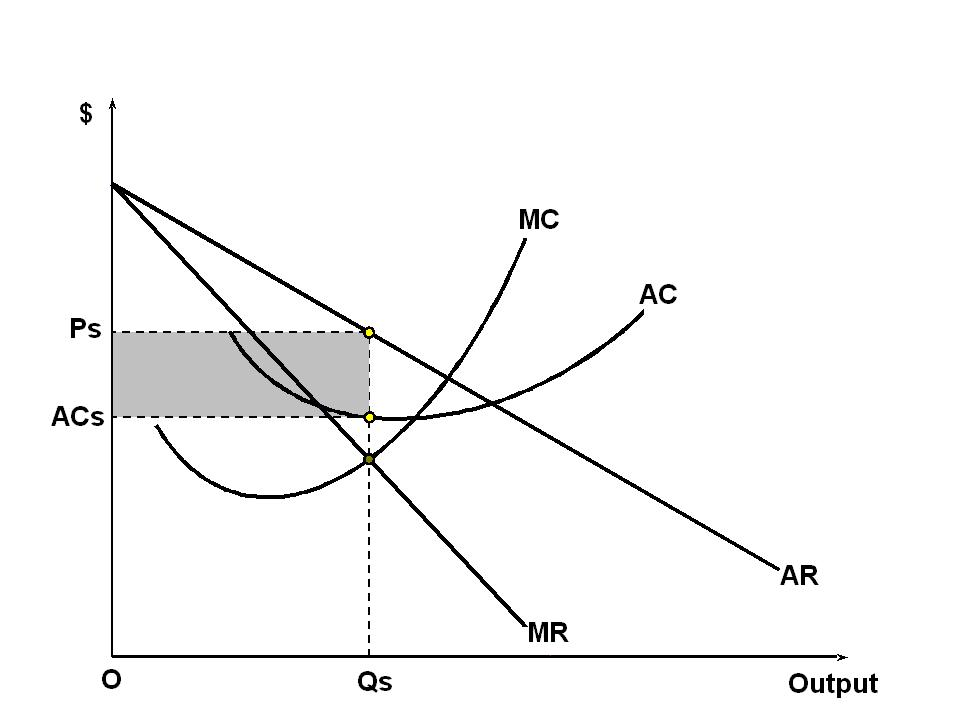

## Product differentiation

**Note:** I originally showed this video in class because it contains a humorous example of product differentiation, but in it one of the actors makes a suggestive and harrassing comment to a woman walking by. His behavior is inappropriate and goes against the classroom code, so I’ve moved the video to this [link](https://www.youtube.com/embed/wJfYAJJYMqg), and am replacing it in the slide with a different one.

[video not shown]

## Wrapping Up

- Complete the [knowledge check](https://goo.gl/forms/ljVuosQeTFgthKKg1) for today’s participation point.
- Please provide [feedback](https://goo.gl/forms/8SiOwdi19kN8cINJ3) on today’s lecture.